# Analyzing the melanoma data with pseudo-observation approaches

In the following, we apply the proposed method to a melanoma data from the Eastern Cooperative Oncology Group phase III clinical trial e1684 (Kirkwood et al. 1996). We illustrated both the mixture cure (MC) and bounded cumulative hazard (BCH) models.

## The Melanoma data

### Data preparation

The dataset is available from the R package `smcure` (Cai et al. 2012):

```r
> data(e1684, package = "smcure")
> head(e1684)
```

```
  TRT FAILTIME FAILCENS         AGE SEX
1   1  1.15068        1 -11.0359437   0
2   1  0.62466        1  -5.1290437   0
3   0  1.89863        0  23.1859563   1
4   0  0.45479        1  11.1448563   1
5   0  2.09041        1 -13.3208437   0
6   1  9.38356        0   0.9421563   0
```

The `e1684` data is a `data.frame` that contains 284 patients and the five variables. The five variables are:

- `TRT` Treatment indicator; 1 = IFN treatment, 0 = control group
- `FAILTIME` Observed relapse-free time; 1 = event
- `FAILCENS` Censoring indicator, 1 = relapse of melanoma happens, 0 = censoring
- `AGE` Patients’ age, centered to the mean
- `SEX` Patients’ gender; 1 = female, 0 = male

The event of interest is the relapse of melanoma and the primary objective is to determine whether the high dose interferon alpha-2b (IFN) regimen in postoperative adjuvant therapy would lead to a significantly prolonged interval of relapse-free for melanoma.

We remove missing values from the original dataset.

```r
> e1684 <- na.omit(e1684)
```

### Checking for cure

The following figure shows the Kaplan-Meier (KM) estimate stratified by `TRT` and `SEX`.

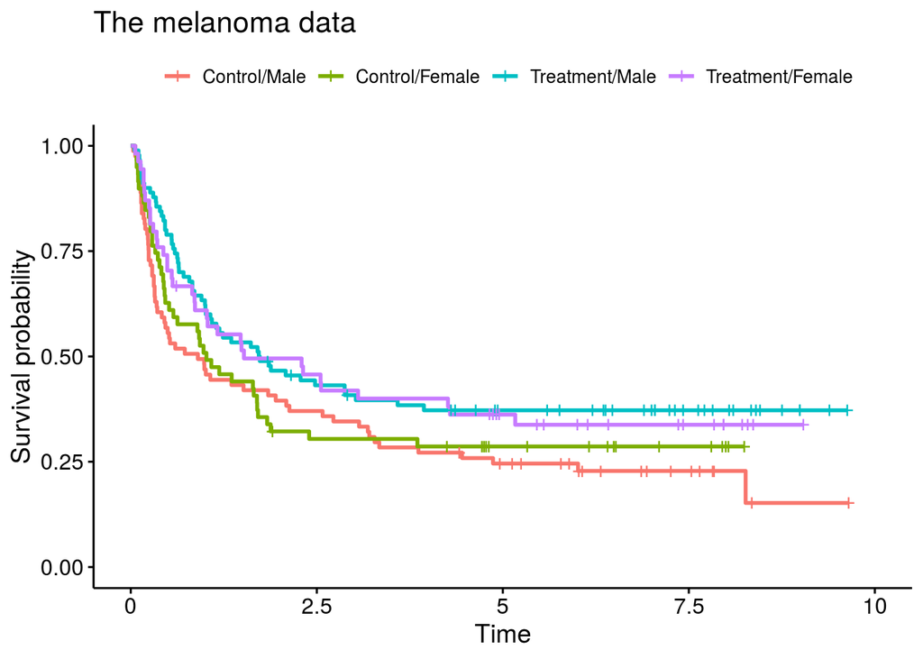

```r
> library(survival)
> library(survminer)
> ggsurvplot(survfit(Surv(FAILTIME, FAILCENS) ~ TRT + SEX, data = e1684),
+            legend.title = "",
+            legend.labs = c("Control/Male", "Control/Female", "Treatment/Male", "Treatment/Female")) +
+   labs(title = "The melanoma data")
```

The KM estimates level off at the end, suggesting a fraction of nonsusceptibility to the recurrence of melanoma. This observation is confirmed by the Maller-Zhou test with a $p$-value of $< 0.001$.

```r
> npcure::testmz(FAILTIME, FAILCENS, e1684)
```

```
Maller-Zhou test

 statistic   n      p.value
        31 284 5.543952e-15
```

## Notations and models

### Notations

We define the following notations.

- $Y$: cure status of a subject;
  - $Y = 1$ if the subject eventually experiences an event (uncured, susceptible)
  - $Y = 0$ if the subject is a survivor (cured, non-susceptible).
- $T$: survival time;
  - $T=YT^{*}+(1-Y)\times\infty$, where $T^{*}<\infty$ is the failure time if the subject is susceptible.
- $\tilde T$: observed survival time;
  - $\tilde{T}=\min\{T,C \}$, where $C$ is the censoring time.
- $\delta$: censoring indicator;
  - $\delta = 1$, the subject experienced an event. This implies $Y=1$.
  - $\delta = 0$, the subject was censored. The cure status $Y$ is not observed.
- $X$ and $Z$ are vectors of covariates with dimensions $p$ and $q$, respectively.

### Mixture cure model

The MC model expresses the population survival function as
$$\begin{equation}
\label{mixture}
S(t)=(1-\pi)+\pi S_{u}(t),
\end{equation}$$
where $\pi=P(Y=1)$ is the uncured rate and $S_{u}(t)$ is the conditional survival function of $T^*$ given $Y=1$. The two components, *incidence* and *latency*, are modeled by the logistic regression model and the Cox proportional hazards model, respectively. We term this the PHMC model.

## MC model: The EM-based approach

The EM-based approach proposed by Peng and Dear (2000) is available in the `smcure()` function from the R package `smcure` (Cai et al. 2012). The arguments of `smcure()` are as follows

```r
> library(smcure)
> packageVersion("smcure")
```

```
[1] '2.0'
```

```r
> args(smcure)
```

```
function (formula, cureform, offset = NULL, data, na.action = na.omit,
    model = c("aft", "ph"), link = "logit", Var = TRUE, emmax = 50,
    eps = 1e-07, nboot = 100)
NULL
```

The main arguments are following (see `?smcure::smcure` for a full list).

- `formula` a formula object to specify the variables included in the **latency** component of the MC model
- `cureform` a formula object to specify the variables included in the **incidence** component of the MC model
- `data` a `data.frame` in which to interpret the variables occurring in the `formula` and `cureform`
- `model` a character string to specify the latency model
- `nboot` an integer to specify number of bootstrap sampling

The following fits `smcure()` to `e1684` with covaraites `AGE`, `TRT`, and `SEX` and 100 bootstrap samples.

```r
> smcure(Surv(FAILTIME, FAILCENS) ~ AGE + TRT + SEX,
+        ~ AGE + TRT + SEX,
+        data = e1684, model = "ph", nboot = 100)
```

```
Program is running..be patient... done.
Call:
smcure(formula = Surv(FAILTIME, FAILCENS) ~ AGE + TRT + SEX,
    cureform = ~AGE + TRT + SEX, data = e1684, model = "ph",
    nboot = 100)

Cure probability model:
               Estimate  Std.Error    Z value     Pr(>|Z|)
(Intercept)  1.36493298 0.29664523  4.6012301 4.200031e-06
AGE          0.02033857 0.01500073  1.3558382 1.751506e-01
TRT         -0.58847727 0.28582681 -2.0588596 3.950769e-02
SEX         -0.08696490 0.28770145 -0.3022748 7.624426e-01


Failure time distribution model:
        Estimate   Std.Error    Z value  Pr(>|Z|)
AGE -0.007664013 0.007276945 -1.0531910 0.2922535
TRT -0.153595097 0.158226552 -0.9707290 0.3316833
SEX  0.099458470 0.178815481  0.5562073 0.5780692
```

There are some drawbacks in the implementation of the `smcure()` function. One of which is in the `cureform` argument, which does not recognize conventional approaches to specifying interaction terms such as `TRT * SEX`. To include the interaction terms `TRT * SEX` in `smcure()`, we need to manually specify the following.

```r
> e1684$TRT.SEX <- e1684$TRT * e1684$SEX
> coxPHMC <- smcure(Surv(FAILTIME, FAILCENS) ~ AGE + TRT + SEX + TRT.SEX,
+                   ~ AGE + TRT + SEX + TRT.SEX,
+                   data = e1684, model = "ph", nboot = 100)
```

```
Program is running..be patient... done.
Call:
smcure(formula = Surv(FAILTIME, FAILCENS) ~ AGE + TRT + SEX +
    TRT.SEX, cureform = ~AGE + TRT + SEX + TRT.SEX, data = e1684,
    model = "ph", nboot = 100)

Cure probability model:
               Estimate  Std.Error    Z value     Pr(>|Z|)
(Intercept)  1.50223792 0.41630324  3.6085184 0.0003079506
AGE          0.01894652 0.01640983  1.1545833 0.2482611111
TRT         -0.86603769 0.48505348 -1.7854478 0.0741887035
SEX         -0.44230981 0.50154549 -0.8818937 0.3778342959
TRT.SEX      0.64803552 0.65497047  0.9894118 0.3224616986


Failure time distribution model:
            Estimate   Std.Error     Z value  Pr(>|Z|)
AGE     -0.007310781 0.006815067 -1.07273798 0.2833887
TRT     -0.012203479 0.241585762 -0.05051407 0.9597127
SEX      0.265837864 0.241669324  1.10000666 0.2713292
TRT.SEX -0.333785304 0.346288343 -0.96389414 0.3350990
```

The estimate of cure rate under the EM-based approach can be computed with the following codes.

```r
> newDat <- expand.grid(TRT = 0:1, SEX = 0:1)
> newDat$AGE <- with(e1684, tapply(AGE, interaction(TRT, SEX), mean))
> newDat$cure.EM <- 1 - 1 / (1 + exp(-model.matrix(~ AGE + TRT * SEX, data = newDat) %*% coxPHMC$b))
> newDat
```

```
  TRT SEX       AGE   cure.EM
1   0   0  0.199186 0.1815306
2   1   0  1.301763 0.3405455
3   0   1 -1.315567 0.2621154
4   1   1 -1.031005 0.3052561
```

## MC model: The proposed pseudo-observation approach

The proposed pseudo-observation approach estimates the regression coefficients in the incidence component and latency component separately.

### Incidence component

The mixture cure model has two parameters, uncured rate $\pi$ and the conditional survival function $S_u(t)$, to be estimated. The cure rate $1 - \pi$ can be estimated by ${\hat{S}_{\scriptsize\text{KM}}}(t_{\max})$, where ${\hat{S}_{\scriptsize\text{KM}}}(t)$ is the Kaplan-Meier (KM) estimator (Maller and Zhou 1992). The following is used to obtain ${\hat{\pi}_{\scriptsize\text{KM}}}= 1 - {\hat{S}_{\scriptsize\text{KM}}}(t_\max)$.

```r
> n <- nrow(e1684)
> tmax <- max(e1684$FAILTIME[e1684$FAILCENS > 0])
> KM <- survfit(Surv(FAILTIME, FAILCENS) ~ 1, data = e1684)
> (cure <- min(KM$surv) )
```

```
[1] 0.2830461
```

The pseudo-observations of ${\hat{\pi}_{\scriptsize\text{KM}}}$ for the $i$th subject is
$${\hat{\pi}^{(i)}_{\scriptsize\text{KM}}}= n\cdot {\hat{\pi}_{\scriptsize\text{KM}}}- (n - 1)\cdot {\hat{\pi}^{(-i)}_{\scriptsize\text{KM}}},$$
where ${\hat{\pi}^{(-i)}_{\scriptsize\text{KM}}}= 1 - {\hat{S}^{(-i)}_{\scriptsize\text{KM}}}(t_\max)$ is the estimator for $\pi$ without the $i$th subject. The following creates a `data.frame` with the pseudo-observations of ${\hat{\pi}_{\scriptsize\text{KM}}}$ stored under `curei`.

```r
> e1684.inc <- e1684
> e1684.inc$id <- 1:n
> e1684.inc$curei <- n * (1 - cure) - sapply(1:n, function(k) {
+   cure.deletei <- min(update(KM, subset = -k)$surv)
+   (n - 1) * (1 - cure.deletei)
+ })
> head(e1684.inc)
```

```
  TRT FAILTIME FAILCENS         AGE SEX TRT.SEX id      curei
1   1  1.15068        1 -11.0359437   0       0  1  1.0025089
2   1  0.62466        1  -5.1290437   0       0  2  1.0025089
3   0  1.89863        0  23.1859563   1       0  3  0.3322519
4   0  0.45479        1  11.1448563   1       0  4  1.0000000
5   0  2.09041        1 -13.3208437   0       0  5  1.0135968
6   1  9.38356        0   0.9421563   0       0  6 -0.4229631
```

The regression coefficient is estimated via GEE.

```r
> library(geepack)
> fit.inc <- geese(curei ~ AGE + TRT * SEX, data = e1684.inc,
+                 jack = TRUE, scale.fix = TRUE, family = gaussian, mean.link = "logit")
>
> summary(fit.inc)
```

```
Call:
geese(formula = curei ~ AGE + TRT * SEX, data = e1684.inc, family = gaussian,
    mean.link = "logit", scale.fix = TRUE, jack = TRUE)

Mean Model:
 Mean Link:                 logit
 Variance to Mean Relation: gaussian

 Coefficients:
              estimate    san.se     ajs.se      wald           p
(Intercept)  1.7374325 0.5832787 0.58447779 8.8728596 0.002894414
AGE          0.0240688 0.0131031 0.01326919 3.3741208 0.066227905
TRT         -1.2945643 0.6307724 0.63259536 4.2121307 0.040135893
SEX         -0.6282064 0.6319217 0.63483844 0.9882758 0.320164152
TRT:SEX      0.9029403 0.7498669 0.75454434 1.4499392 0.228537712

Scale is fixed.

Correlation Model:
 Correlation Structure:     independence

Returned Error Value:    0
Number of clusters:   284   Maximum cluster size: 1
```

We follow the idea of pseudo-residuals Andersen and Perme (2010) to assess the goodness-of-fit. We calculate and plot the pseudo residuals with the following code.

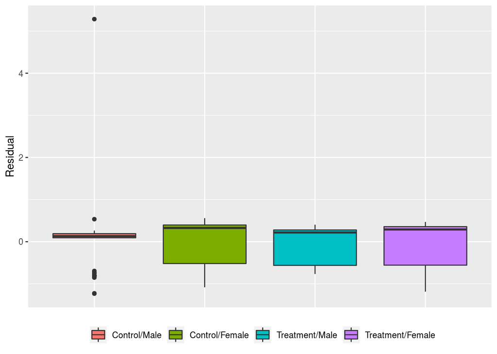

```r
> e1684.inc$resid <- e1684.inc$curei -
+   1 / (exp(-model.matrix(~ AGE + TRT * SEX, e1684.inc) %*% fit.inc$beta) + 1)
> ggplot(e1684.inc, aes(x = interaction(TRT, SEX), y = resid, fill = interaction(TRT, SEX))) +
+   geom_boxplot() + ylab("Residual") +
+   scale_fill_discrete(labels = c("Control/Male", "Control/Female",
+                                  "Treatment/Male", "Treatment/Female")) +
+   theme(axis.text.x = element_blank(),
+         axis.title.x = element_blank(),
+         axis.ticks.x = element_blank(),
+         legend.title = element_blank(),
+         legend.position = "bottom")
```

The estimate of cure rate under the proposed pseudo-observation based approach can be computed with the following codes.

```r
> newDat$cure.ps <- 1 - 1 / (1 + exp(-model.matrix(~ AGE + TRT * SEX, data = newDat) %*% fit.inc$b))
> newDat
```

```
  TRT SEX       AGE   cure.EM   cure.ps
1   0   0  0.199186 0.1815306 0.1490303
2   1   0  1.301763 0.3405455 0.3836226
3   0   1 -1.315567 0.2621154 0.2539677
4   1   1 -1.031005 0.3052561 0.3334134
```

### Latency component

To estimate the regression coefficient in the latency component, we need to create pseudo-observations for $S_u(t)$. The MC model implies $S_u(t)$ can be estimated by
$$\hat{S}_u(t) = \frac{ {\hat{S}_{\scriptsize\text{KM}}}(t) - {\hat{S}_{\scriptsize\text{KM}}}(t_\max)}{1 - {\hat{S}_{\scriptsize\text{KM}}}(t_\max)}.$$
Thus, the pseudo-observation for $S_u(t)$ can be constructed by
$$\begin{equation*}
{\hat{S}^{(i)}_u}(t) = n\cdot {\hat{S}_u}(t) - (n - 1)\cdot {\hat{S}^{(-i)}_u}(t),
\end{equation*}$$
where
$$\begin{equation*}
{\hat{S}^{(-i)}_u}(t) = \frac{ {\hat{S}^{(-i)}_u}(t) - {\hat{S}^{(-i)}_u}(t_\max)}{1 - {\hat{S}^{(-i)}_u}(t_\max)}
\end{equation*}$$
is the estimator for $S_u(t)$ without the $i$ subject. The following creates a `data.frame` with the pseudo-observations of $S_u(t)$ at $t = \{t_1, \ldots, t_H\}$ stored under variable `Si`. We consider the pseudo-observation times $t$ at the $10, 20, \ldots, 80, 90$, and the 95th percentiles of the observed survival times.

```r
> t0 <- quantile(e1684$FAILTIME[e1684$FAILCENS > 0], c(1:9 / 10, .95))
> S <- KM$surv[findInterval(t0, KM$time)]
> e1684.lat <- e1684[rep(1:n, each = length(t0)),]
> e1684.lat$id <- rep(1:n, each = length(t0))
> e1684.lat$Si <- n * (S - cure) / (1 - cure) - c(sapply(1:n, function(k) {
+   KM.reduce <- update(KM, subset = -k)
+   S.deletei <- KM.reduce$surv[findInterval(t0, KM.reduce$time)]
+   cure.deletei <- min(KM.reduce$surv)
+   (n - 1) * (S.deletei - cure.deletei) / (1 - cure.deletei)
+ }))
> e1684.lat$Fi <- 1 - e1684.lat$Si
> e1684.lat$t <- as.factor(rep(t0, n))
> rownames(e1684.lat) <- NULL
> head(e1684.lat)
```

```
  TRT FAILTIME FAILCENS       AGE SEX TRT.SEX id       Si          Fi       t
1   1  1.15068        1 -11.03594   0       0  1 1.039315 -0.03931539 0.13014
2   1  1.15068        1 -11.03594   0       0  1 1.080597 -0.08059655 0.19452
3   1  1.15068        1 -11.03594   0       0  1 1.115980 -0.11598040 0.29452
4   1  1.15068        1 -11.03594   0       0  1 1.155296 -0.15529579 0.41644
5   1  1.15068        1 -11.03594   0       0  1 1.194611 -0.19461118 0.55068
6   1  1.15068        1 -11.03594   0       0  1 1.232728 -0.23272828 0.86301
```

Generalized linear model with a log function, $\log\{-\log(x)\}$, is used to estimate the regression coefficients in the latency component. However, the complementary log-log link function in standard R approaches, e.g., `geese()`, corresponds to $\log\{\log(x)\}$. We thus fit a GEE model with `Fi` as the response variable.

```r
> fit.lat <- geese(Fi ~ 0 + t + AGE + TRT * SEX, data = e1684.lat, id = id,
+                 jack = TRUE, scale.fix = TRUE, family = gaussian, mean.link = "cloglog")
> summary(fit.lat)
```

```
Call:
geese(formula = Fi ~ 0 + t + AGE + TRT * SEX, id = id, data = e1684.lat,
    family = gaussian, mean.link = "cloglog", scale.fix = TRUE,
    jack = TRUE)

Mean Model:
 Mean Link:                 cloglog
 Variance to Mean Relation: gaussian

 Coefficients:
               estimate      san.se      ajs.se         wald            p
t0.13014   -2.324555919 0.334285749 0.329000404 4.835532e+01 3.555822e-12
t0.19452   -1.546151979 0.293532609 0.289516594 2.774544e+01 1.383738e-07
t0.29452   -1.102452532 0.281838449 0.278232037 1.530098e+01 9.166882e-05
t0.41644   -0.740457898 0.274742063 0.271360702 7.263575e+00 7.036708e-03
t0.55068   -0.435921854 0.270171437 0.266927358 2.603385e+00 1.066357e-01
t0.86301   -0.170745386 0.269036080 0.265827715 4.027883e-01 5.256527e-01
t1.120545   0.088336035 0.271942092 0.268659188 1.055171e-01 7.453067e-01
t1.72055    0.368536876 0.283437527 0.279856485 1.690625e+00 1.935186e-01
t2.79863    0.675217085 0.306452380 0.302295832 4.854683e+00 2.757118e-02
t3.6527375  0.871497910 0.333981301 0.329159514 6.809079e+00 9.069551e-03
AGE        -0.008972261 0.007109114 0.007073537 1.592843e+00 2.069205e-01
TRT        -0.009234226 0.302953436 0.299316036 9.290717e-04 9.756837e-01
SEX         0.151249061 0.313706676 0.310397907 2.324544e-01 6.297098e-01
TRT:SEX    -0.151309150 0.386721501 0.383187257 1.530854e-01 6.956041e-01

Scale is fixed.

Correlation Model:
 Correlation Structure:     independence

Returned Error Value:    0
Number of clusters:   284   Maximum cluster size: 10
```

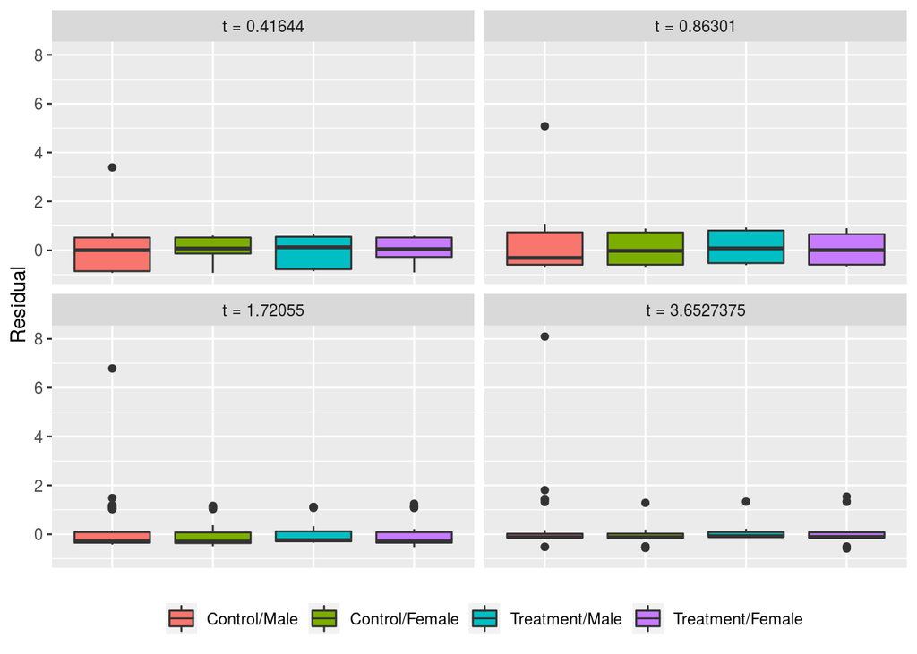

```r
> e1684.lat$resid <-
+   e1684.lat$Si - exp(-exp(model.matrix(~ 0 + t + AGE + TRT * SEX, e1684.lat) %*% fit.lat$beta))
> levels(e1684.lat$t) <- paste0("t = ", unique(e1684.lat$t))
> ggplot(subset(e1684.lat, t0 %in% t0[2:5 * 2]),
+        aes(x = interaction(TRT, SEX), y = resid, fill = interaction(TRT, SEX))) +
+   facet_wrap(~ t) + geom_boxplot() + ylab("Residual") +
+   scale_fill_discrete(labels = c("Control/Male", "Control/Female",
+                                  "Treatment/Male", "Treatment/Female")) +
+   theme(axis.text.x = element_blank(),
+         axis.title.x = element_blank(),
+         axis.ticks.x = element_blank(),
+         legend.title = element_blank(),
+         legend.position = "bottom")
```

The pseudo-residuals fluctuate around zero, indicating the adequacy of the proposed GLM even though the pseudo-residuals have a larger variation in the Control/Male group.

## BCH model

As in the MC model, the proposed pseudo-observation approach allows the **short-term** and **long-term** covaraites effects in the BCH model to be estimated separately.

### Long-term effect

Since the cure rate $\lim_{t\rightarrow \infty}S(t)=\exp(-\theta)$ can be nonparametrically estimated by ${\hat{S}_{\scriptsize\text{KM}}}(t_{\max})$, $\theta$ can be estimated by ${\hat{\theta}_{\scriptsize\text{KM}}}=-\log {\hat{S}_{\scriptsize\text{KM}}}(t_{\max})$. The pseudo-observation of ${\hat{\theta}_{\scriptsize\text{KM}}}$ for the $i$th subject is
$$\begin{equation*}
{\hat{\theta}^{(i)}_{\scriptsize\text{KM}}}= n\cdot {\hat{\theta}_{\scriptsize\text{KM}}}- (n - 1)\cdot {\hat{\theta}^{(-i)}_{\scriptsize\text{KM}}}.
\end{equation*}$$
The following codes create a `data.frame` with the pseudo-observation for ${\hat{\theta}_{\scriptsize\text{KM}}}$ stored under `thetai`.

```r
> e1684.long <- e1684
> e1684.long$id <- 1:n
> e1684.long$thetai <- n * (-log(cure)) - sapply(1:n, function(k) {
+   cure.deletei <- min(update(KM, subset = -k)$surv)
+   (n - 1) * (-log(cure.deletei))
+ })
> head(e1684.long)
```

```
  TRT FAILTIME FAILCENS         AGE SEX TRT.SEX id     thetai
1   1  1.15068        1 -11.0359437   0       0  1  2.2692153
2   1  0.62466        1  -5.1290437   0       0  2  2.2692153
3   0  1.89863        0  23.1859563   1       0  3 -0.1002781
4   0  0.45479        1  11.1448563   1       0  4  2.2603828
5   0  2.09041        1 -13.3208437   0       0  5  2.3082471
6   1  9.38356        0   0.9421563   0       0  6 -2.7941042
```

The regression coefficient is estimated via GEE.

```r
> fit.long <- geese(thetai ~ AGE + TRT * SEX, data = e1684.long,
+                   jack = TRUE, scale.fix = TRUE, family = gaussian, mean.link = "log")
> summary(fit.long)
```

```
Call:
geese(formula = thetai ~ AGE + TRT * SEX, data = e1684.long,
    family = gaussian, mean.link = "log", scale.fix = TRUE, jack = TRUE)

Mean Model:
 Mean Link:                 log
 Variance to Mean Relation: gaussian

 Coefficients:
               estimate      san.se      ajs.se      wald            p
(Intercept)  0.53815300 0.162711087 0.163561209 10.938990 0.0009416148
AGE          0.01168842 0.005795896 0.005859644  4.066963 0.0437298287
TRT         -0.66831936 0.265480522 0.266425133  6.337278 0.0118226175
SEX         -0.25903919 0.216476410 0.218277755  1.431890 0.2314561568
TRT:SEX      0.45280522 0.374892253 0.378067592  1.458848 0.2271135775

Scale is fixed.

Correlation Model:
 Correlation Structure:     independence

Returned Error Value:    0
Number of clusters:   284   Maximum cluster size: 1
```

We calculate and plot the pseudo residuals with the following code.

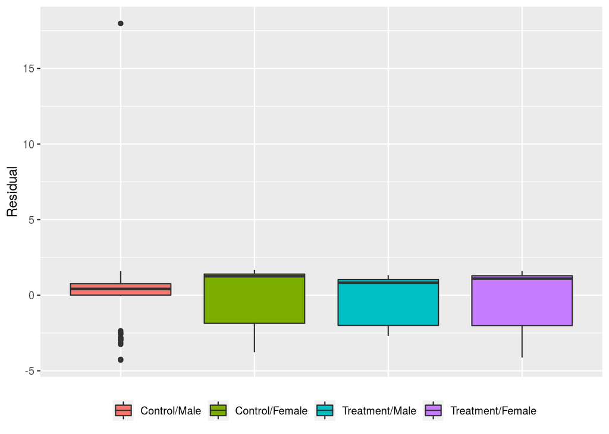

```r
> e1684.long$resid <- e1684.long$thetai -
+   exp(model.matrix(~ AGE + TRT * SEX, e1684.long) %*% fit.long$beta)
> ggplot(e1684.long, aes(x = interaction(TRT, SEX), y = resid, fill = interaction(TRT, SEX))) +
+   geom_boxplot() + ylab("Residual") +
+   scale_fill_discrete(labels = c("Control/Male", "Control/Female",
+                                  "Treatment/Male", "Treatment/Female")) +
+   theme(axis.text.x = element_blank(),
+         axis.title.x = element_blank(),
+         axis.ticks.x = element_blank(),
+         legend.title = element_blank(),
+         legend.position = "bottom")
```

### Short-term effect

Based Tsodikov (2002), $F(t)$ can be consistently estimated by ${\hat{F}_{\scriptsize\text{KM}}}(t)=\log( {\hat{S}_{\scriptsize\text{KM}}}(t))/\log( {\hat{S}_{\scriptsize\text{KM}}}(t_{\max}))$. Thus, the pseudo-observations for $F(t)$ can be created by
$$\begin{equation*}
{\hat{F}^{(i)}_{\scriptsize\text{KM}}}(t)=n\cdot {\hat{F}_{\scriptsize\text{KM}}}(t)-(n-1)\cdot {\hat{F}^{(-i)}_{\scriptsize\text{KM}}}(t),
\end{equation*}$$
where ${\hat{F}^{(-i)}_{\scriptsize\text{KM}}}(t)$ is the estimate of ${\hat{F}_{\scriptsize\text{KM}}}(t)$ without the $i$th subject.

The following creates a `data.frame` with the pseudo-observations of $F(u)$ stored under variable `Fi`. We consider the pseudo-observation times $t$ at the $10,20, \ldots, 80,90$, and the 95th percentiles of the observed survival times.

```r
> e1684.short <- e1684[rep(1:n, each = length(t0)),]
> e1684.short$id <- rep(1:n, each = length(t0))
> e1684.short$Fi <- n * (log(S) / log(cure)) - c(sapply(1:n, function(k) {
+   KM.reduce <- update(KM, subset = -k)
+   S.deletei <- KM.reduce$surv[findInterval(t0, KM.reduce$time)]
+   cure.deletei <- min(KM.reduce$surv)
+   (n - 1) * log(S.deletei) / log(cure.deletei)
+ }))
> e1684.short$t <- as.factor(rep(t0, n))
> rownames(e1684.short) <- NULL
> head(e1684.short)
```

```
  TRT FAILTIME FAILCENS       AGE SEX TRT.SEX id          Fi       t
1   1  1.15068        1 -11.03594   0       0  1 -0.04863825 0.13014
2   1  1.15068        1 -11.03594   0       0  1 -0.10941217 0.19452
3   1  1.15068        1 -11.03594   0       0  1 -0.17157125 0.29452
4   1  1.15068        1 -11.03594   0       0  1 -0.25478671 0.41644
5   1  1.15068        1 -11.03594   0       0  1 -0.35772487 0.55068
6   1  1.15068        1 -11.03594   0       0  1 -0.48164892 0.86301
```

Generalized linear model with a log function, $\log\{−\log(x)\}$, is used to estimate the regression coefficients in the latency component.

```r
> fit.short <- geese(Fi ~ 0 + t + AGE + TRT * SEX, data = e1684.short,
+              jack = TRUE, scale.fix = TRUE, family = gaussian, mean.link = "cloglog")
> summary(fit.short)
```

```
Call:
geese(formula = Fi ~ 0 + t + AGE + TRT * SEX, data = e1684.short,
    family = gaussian, mean.link = "cloglog", scale.fix = TRUE,
    jack = TRUE)

Mean Model:
 Mean Link:                 cloglog
 Variance to Mean Relation: gaussian

 Coefficients:
              estimate     san.se     ajs.se         wald            p
t0.13014   -3.34225296 0.52225927 0.51459150 40.954941928 1.557796e-10
t0.19452   -2.52516181 0.49571928 0.48885797 25.948174439 3.507069e-07
t0.29452   -2.06014812 0.48561249 0.47904030 17.997708072 2.211711e-05
t0.41644   -1.66336052 0.47758399 0.47120959 12.130348080 4.960786e-04
t0.55068   -1.31500863 0.46952901 0.46333871  7.843905444 5.099232e-03
t0.86301   -0.99307095 0.46116600 0.45515527  4.637095069 3.128792e-02
t1.120545  -0.69186134 0.45601970 0.45010377  2.301817681 1.292227e-01
t1.72055   -0.34380722 0.45393372 0.44802335  0.573647495 4.488131e-01
t2.79863    0.02355137 0.46503901 0.45885776  0.002564801 9.596093e-01
t3.6527375  0.25011936 0.48737171 0.48074683  0.263374659 6.078111e-01
AGE        -0.01675822 0.01022578 0.01015511  2.685736432 1.012504e-01
TRT         0.56528251 0.49322855 0.48691605  1.313513938 2.517594e-01
SEX         0.53712225 0.47538205 0.46954676  1.276617305 2.585289e-01
TRT:SEX    -0.68944861 0.56289672 0.55691321  1.500190322 2.206421e-01

Scale is fixed.

Correlation Model:
 Correlation Structure:     independence

Returned Error Value:    0
Number of clusters:   284   Maximum cluster size: 10
```

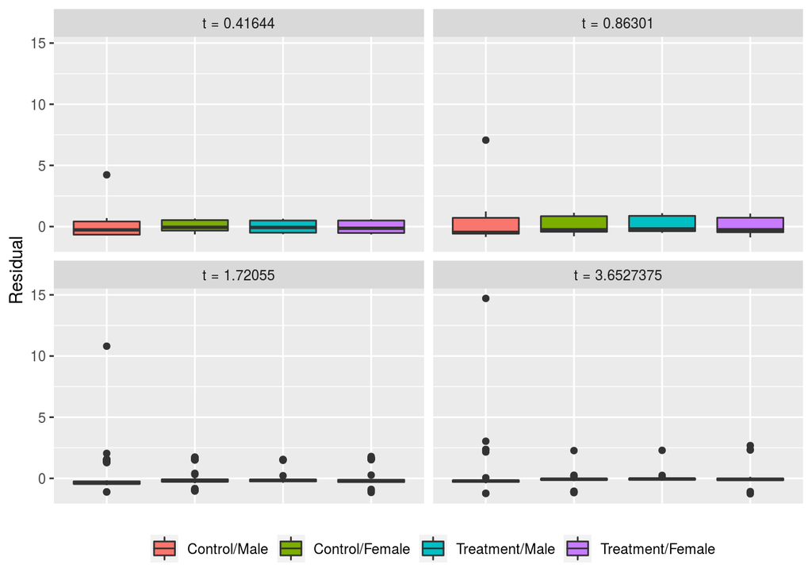

```r
> e1684.short$resid <- 1 - e1684.short$Fi - exp(-exp(
+   model.matrix(~ 0 + t + AGE + TRT * SEX, e1684.short) %*% fit.short$beta))
> levels(e1684.short$t) <- paste0("t = ", unique(e1684.short$t))
> ggplot(subset(e1684.short, t0 %in% t0[2:5 * 2]),
+        aes(x = interaction(TRT, SEX), y = resid, fill = interaction(TRT, SEX))) +
+   facet_wrap(~ t) + geom_boxplot() + ylab("Residual") +
+   scale_fill_discrete(labels = c("Control/Male", "Control/Female",
+                                  "Treatment/Male", "Treatment/Female")) +
+   theme(axis.text.x = element_blank(),
+         axis.title.x = element_blank(),
+         axis.ticks.x = element_blank(),
+         legend.title = element_blank(),
+         legend.position = "bottom")
```

## Reference

Andersen, P. K., and M. Pohar Perme. 2010. “Pseudo-Observations in Survival Analysis.” *Statistical Methods in Medical Research* 19 (1): 71–99.

Cai, C., Y. Zou, Y. Peng, and J. Zhang. 2012. “Smcure: An R-Package for Estimating Semiparametric Mixture Cure Models.” *Comput Methods Programs Biomed* 108 (3): 1255–60.

Kirkwood, J. M., M. H. Strawderman, M. S. Ernstoff, T. J. Smith, E. C. Borden, and R. H. Blum. 1996. “Interferon Alfa-2b Adjuvant Therapy of High-Risk Resected Cutaneous Melanoma: The Eastern Cooperative Oncology Group Trial Est 1684.” *J. Clin. Oncol.* 14 (1): 7–17.

Maller, R. A., and S. Zhou. 1992. “Estimating the Proportion of Immunes in a Censored Sample.” *Biometrika* 79 (4): 731–39.

Peng, Y., and K. B. G. Dear. 2000. “A Nonparametric Mixture Model for Cure Rate Estimation.” *Biometrics* 56 (1): 237–43.

Tsodikov, A. 2002. “Semi-Parametric Models of Long-and Short-Term Survival: An Application to the Analysis of Breast Cancer Survival in Utah by Age and Stage.” *Stat Med* 21 (6): 895–920.

Tsodikov, A., J. G. Ibrahim, and A. Y. Yakovlev. 2003. “Estimating Cure Rates from Survival Data: An Alternative to Two-Component Mixture Models.” *Journal of the American Statistical Association* 98 (464): 1063–78.